# Chapter 2: Overview of Supervised Learning

# 2.4 Statistical Decision Theory

> We seek a function $f(X)$ for predicting $Y$ given values of the input $X$. This theory requires a loss function $L(Y,f(X))$ for penalizing errors in prediction, and by far the most common and convenient is squared error loss: $L(Y,f(X)) = (Y − f(X))^2$.

This leads us to a criterion for choosing $f$, the expected (squared) prediction error:

$$\begin{align}
\text{EPE}(f) &= \text{E} (Y - f(X))^2 \tag{2.9} \\
&= \int [y - f(x)]^2 \text{Pr}(dx, dy) \tag{2.10}
\end{align}$$

The solution to minimize the EPE is the conditional expectation, also known as the *regression* function:

$$f(x) = \text{E}(Y | X = x) \tag{2.13}$$

In nearest-neighbor methods, we make the assumptions that (1) expectation is approximated by averaging over sample data ($\text{Ave}(y|x)$), and (2) conditioning to the point ($X = x_i$) is relaxed to some region “close” to the target point ($x_i \in N_k(x)$):

$$\hat{f}_x = \text{Ave}(y_i | x_i \in N_k (x)) \tag{2.14}$$

Linear regression is a model-based approach where we assume $f(x)$ is well-approximated by a globally linear function:

$$f(x) \approx x^T \beta \tag{2.15}$$

In the case of predicting a categorical variable $G$ with possible values $\mathcal{G}$, the loss function is represented by a $K \times K$ matrix $\bf{L}$ where $K = \text{card}(\mathcal{G})$ (cardinality of a set is the number of elements, so the number of possible values $G$ can take). $\bf{L}$ will be zero on the diagonal and non-negative ($L(k,l)$) elsewhere. Most often, we use the *zero-one* loss function, where $L(k,l) = 1$ if $\mathcal{G}_k \neq \mathcal{G}_l$

For instance, if $\mathcal{G} =$ {BLUE, ORANGE} then the $2 \times 2$ loss matrix would look like:

$$\bf{L} =
\begin{bmatrix}
0 & L(\text{ORANGE}, \text{BLUE}) = 1 \\
L(\text{BLUE}, \text{ORANGE}) = 1 & 0
\end{bmatrix}$$
The `discrim` package is an extension to `parsnip` which provides additional model definitions for discriminant analysis, including naive Bayes.

```r
library(discrim, quietly = TRUE)
nb_spec <- naive_Bayes() %>%
  # The mode is always classification with NB, so this line can be omitted
  set_mode("classification") %>%
  # Note that this engine requires the "naivebayes" package to be installed
  # The other option is "klaR", as per parsnip::show_engines("naive_Bayes")
  #  but that also requires the package of the same name
  set_engine("naivebayes")
translate(nb_spec)
```

```
## Naive Bayes Model Specification (classification)
##
## Computational engine: naivebayes
##
## Model fit template:
## naivebayes::naive_bayes(x = missing_arg(), y = missing_arg(),
##     usekernel = TRUE)
```

```r
nb_fit_mixture <- nb_spec %>%
  fit(factor(y) ~ x1 + x2, data = d_mixture)
```

The output from the model is very long and confusing:

```r
nb_fit_mixture
```

```
## parsnip model object
##
## Fit time:  0ms
##
## ================================== Naive Bayes ==================================
##
##  Call:
## naive_bayes.default(x = maybe_data_frame(x), y = y, usekernel = TRUE)
##
## ---------------------------------------------------------------------------------
##
## Laplace smoothing: 0
##
## ---------------------------------------------------------------------------------
##
##  A priori probabilities:
##
##   0   1
## 0.5 0.5
##
## ---------------------------------------------------------------------------------
##
##  Tables:
##
## ---------------------------------------------------------------------------------
##  ::: x1::0 (KDE)
## ---------------------------------------------------------------------------------
##
## Call:
##  density.default(x = x, na.rm = TRUE)
##
## Data: x (100 obs.);  Bandwidth 'bw' = 0.3999
##
##        x                 y
##  Min.   :-2.1123   Min.   :0.0001129
##  1st Qu.:-0.2416   1st Qu.:0.0142928
##  Median : 1.6291   Median :0.1156527
##  Mean   : 1.6291   Mean   :0.1335060
##  3rd Qu.: 3.4997   3rd Qu.:0.2301978
##  Max.   : 5.3704   Max.   :0.3180232
```

[output cut: 38 more lines]

```
##
## Call:
##  density.default(x = x, na.rm = TRUE)
##
## Data: x (100 obs.);  Bandwidth 'bw' = 0.2693
##
##        x                  y
##  Min.   :-1.13875   Min.   :0.0003009
##  1st Qu.: 0.06189   1st Qu.:0.0356972
##  Median : 1.26253   Median :0.1948295
##  Mean   : 1.26253   Mean   :0.2080094
##  3rd Qu.: 2.46318   3rd Qu.:0.3358978
##  Max.   : 3.66382   Max.   :0.5201881
##
## ---------------------------------------------------------------------------------
```

Let’s treat it as a black box compute the error on the training and testing sets:

```r
nb_fits_mixture_error <-
  tibble(
    nb_fit = list(nb_fit_mixture)
  ) %>%
  mutate(
    train = map_dbl(
      nb_fit,
      function(nb_fit) {
        augment(nb_fit, d_mixture) %>%
          mutate(y = factor(y)) %>%
          summarise(error = 1 - mean(y == .pred_class)) %>%
          pull(error)
      }
    ),
    test = map_dbl(
      nb_fit,
      function(nb_fit) {
        augment(nb_fit, d_sim_mixture) %>%
          mutate(y = factor(y)) %>%
          summarise(error = 1 - mean(y == as.numeric(.pred_class))) %>%
          pull(error)
      }
    )
  ) %>%
  pivot_longer(cols = c(train, test), names_to = "dataset", values_to = "error")
nb_fits_mixture_error
```

| nb_fit | dataset | error |
| --- | --- | --- |
|  | train | 0.2100 |
|  | test | 0.8979 |

Terrible performance on the testing set, but looks like the same training error as in the figure, which we can finally complete:

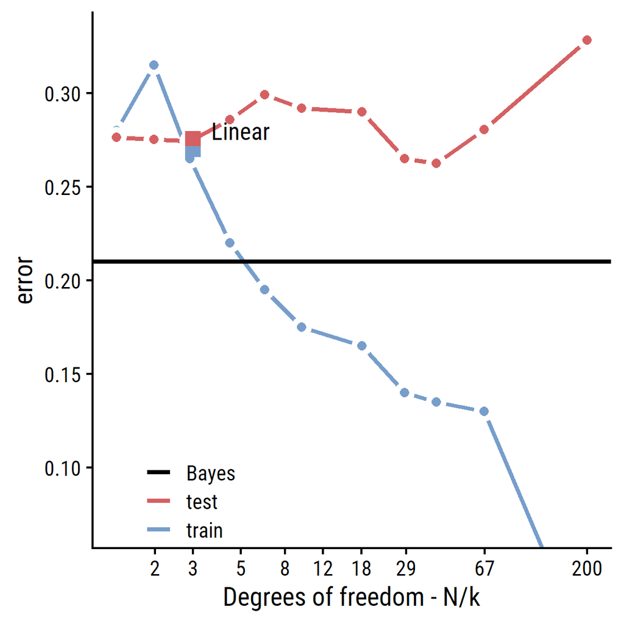

```r
p_fig2.4 +
  geom_hline(
    data = nb_fits_mixture_error %>%
      filter(dataset == "train") %>%
      mutate(dataset = "Bayes"),
    aes(yintercept = error, color = dataset), size = 1
  ) +
  scale_color_manual(values = c("black", td_colors$pastel6[1:2]))
```

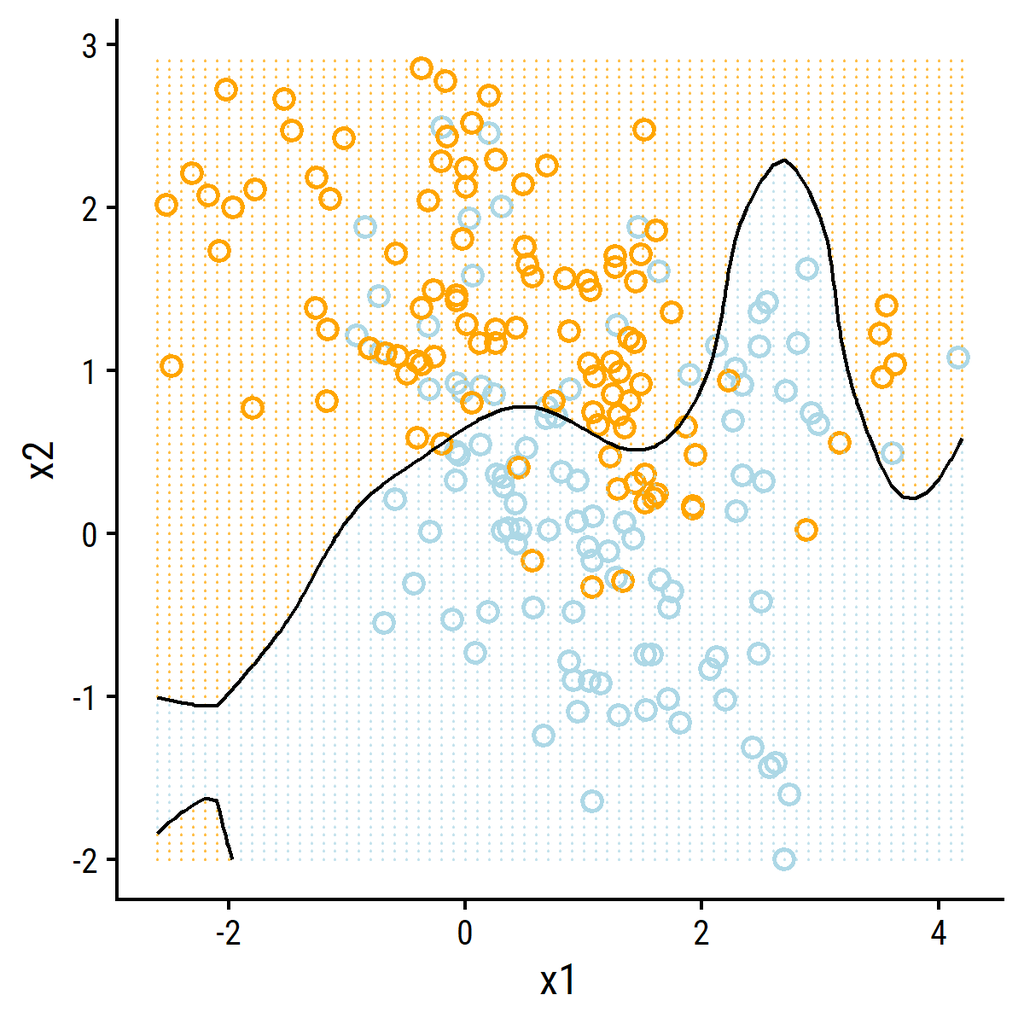

```r
d_mixture_grid_nb_pred <- augment(nb_fit_mixture, d_mixture_grid)

p_fig2.5 <- d_mixture %>%
  ggplot(aes(x = x1, y = x2)) +
  geom_point(aes(color = factor(y)), shape = 21, size = 2, stroke = 1) +
  scale_color_manual(values = c("lightblue", "orange")) +
  theme(legend.position = "none") +
  geom_point(
    data = d_mixture_grid_nb_pred,
    aes(color = .pred_class), size = 0.05, alpha = 0.5
  ) +
  stat_contour(
    data = d_mixture_grid_nb_pred, aes(z = .pred_0),
    color = "black", breaks = c(0.5)
  )
p_fig2.5
```

It kind of looks correct if you squint. There are some confusing areas, like the bit of orange in the bottom left corner. It may have something to do with the way I specified the naive Bayes classifier.

# 2.5 Local Methods in High Dimensions

The $k$-nearest-neighbor approach breaks down in high dimensions, a phenomenon commonly referred to as the *curve of dimensionality*.

Consider a target point in a $p$-dimensional unit hypercube. The local neighborhood of the target point is also a hypercube of edge length $e_p(r) = r^{1/p}$, where $r$ is the fraction of the unit volume. If we want to capture $r = 0.1$ of the observations in a $p = 10$-dimensional space, then the neighborhood will have edge length $e_{10}(0.1) = 0.8$, i.e. 80% of the full hypercube. This is no longer a “local” neighborhood, and reducing $r$ just increases the variance of our fit.

Show this relationship as in Figure 2.6 (right):

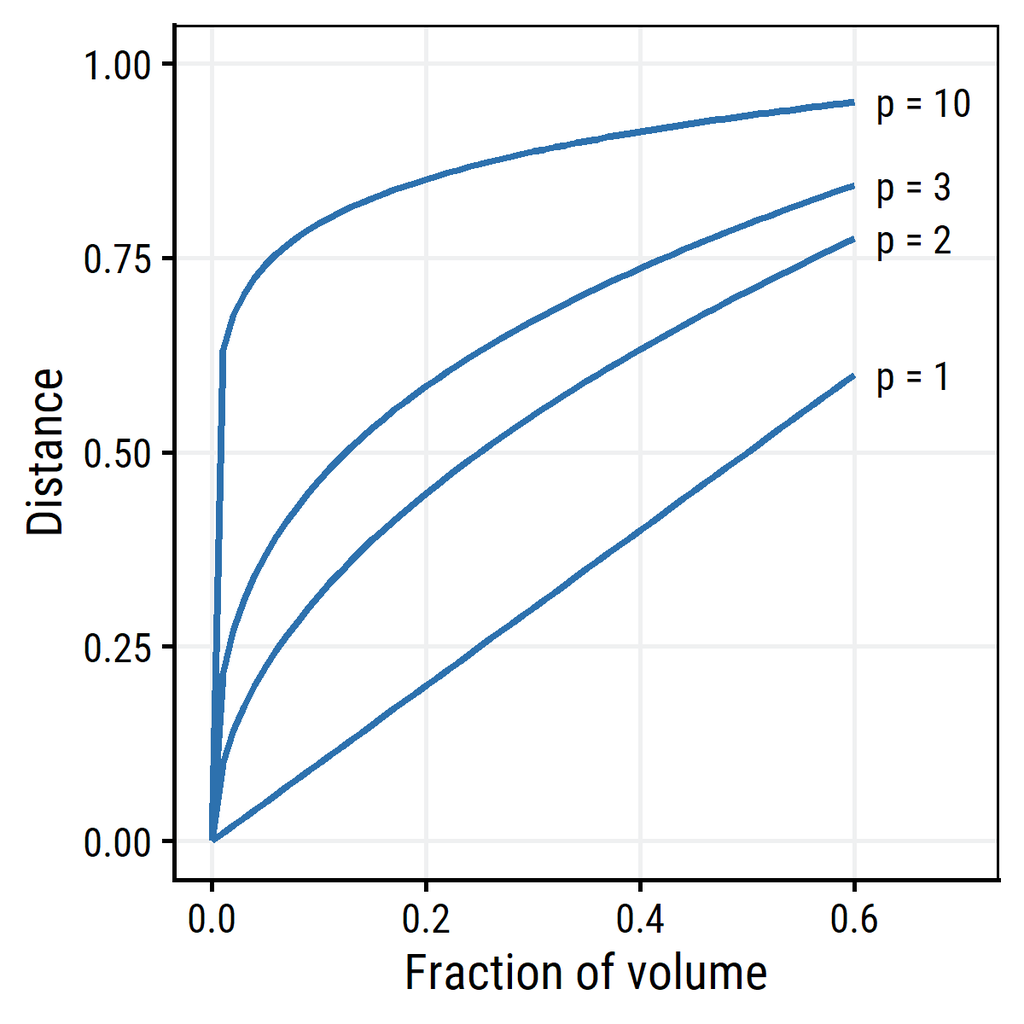

```r
p_fig2.6 <-
  crossing(
    p = c(1, 2, 3, 10),
    r = seq(0, 0.6, 0.01)
  ) %>%
  mutate(dist = r^(1 / p)) %>%
  ggplot(aes(x = r, y = dist, group = p)) +
  geom_line(color = td_colors$nice$spanish_blue, size = 1) +
  geom_text(
    data = . %>% filter(r == 0.6),
    aes(label = glue("p = {p}")), hjust = 0, nudge_x = 0.02
  ) +
  theme_td_grid(base_family = "Roboto Condensed") +
  labs(x = "Fraction of volume", y = "Distance") +
  ylim(c(0, 1.0)) +
  xlim(c(0, 0.7))
p_fig2.6
```

> Suppose we have 1000 training examples $x_i$ generated uniformly on $[−1,1]^p$. Assume that the true relationship between X and Y is.
> $$Y = f(X) = e^{−8||X||^2}$$
> without any measurement error. We use the 1-nearest-neighbor rule to predict $y_0$ at the test point $x_0 = 0$.

# Reproducibility

**Reproducibility receipt**

```r
Sys.time()
```

```
## [1] "2021-05-09 22:15:25 AST"
```

```r
if ("git2r" %in% installed.packages()) {
  if (git2r::in_repository()) {
    git2r::repository()
  }
}
```

```
## Local:    main C:/Users/Taylor/Documents/learning/textbooks/elements-of-statistical-learning
## Remote:   main @ origin (https://github.com/taylordunn/elements-of-statistical-learning.git)
## Head:     [1454682] 2021-05-09: Section 2.3.1
```

# References

Hastie, T., Tibshirani, R., & Friedman, J. (2009). *The Elements of Statistical Learning*. Springer New York. https://doi.org/10.1007/978-0-387-84858-7